# SEGMENTATION DES CLIENTS D' UN e-COMMERCE:

# Sommaire :

### **Préambule**

- 1) Présentation du sujet
- 2) Présentation des fichier

### **Présentation des fichiers**

- 1) olist_customers_dataset.csv
- 2) olist_geolocation_dataset.csv
- 3) olist_orders_dataset.csv
- 4) olist_order_items_dataset.csv
- 5) olist_order_payments_dataset.csv
- 6) olist_order_reviews_dataset.csv
- 7) olist_products_dataset.csv
- 8) olist_sellers_dataset.csv
- 9) product_category_name_translation.csv

### **Synthèse et sauvegarde**

- 1) Synthèse et exploration du dataset final
- 2) Selection et création de variables
- 3) Corrélations

# Préambule

## 1) Présentation du sujet

Notre objectif est réaliser une segmentation des clients du site de vente en ligne Olist. Les données récupérées sont séparées en 9 fichiers que nous analyserons succintement avant de les regrouper. Nous utiliserons ensuite ces données aggrégées ultérieurement afin de proposer différents modèles de segmentation.

### Présentation des bibliothèques

```python
from datetime import datetime, timedelta
from deep_translator import GoogleTranslator
from sklearn.metrics.pairwise import haversine_distances
from math import radians
import importlib.metadata
import math
import matplotlib.pyplot as plt
import nltk
import random
import missingno as msno
import numpy as np
import os
import pandas as pd
import re
import seaborn as sns
!python --version
print('\n'.join(f'{m.__name__} {m.__version__}'
                for m in globals().values()
                if getattr(m, '__version__', None)))
plt.rcParams.update({'font.size': 18})
```

```
Python 3.9.7
nltk 3.8.1
missingno 0.4.1
numpy 1.23.5
pandas 1.3.4
re 2.2.1
seaborn 0.12.2
```

### Présentation des fonctions d'affichage de graphiques

```python
# Graphique en camembert
def distribution_variables_object3(variable,x,y,titre,coupe=None):
    vect_description=variable.value_counts(normalize=True)
    if coupe is not None :
        vect_description_new= vect_description[vect_description>coupe]
        d={'autres':1-vect_description_new.sum()}
        ser=pd.Series(d,copy=False)
        vect_description_new=vect_description_new.append(ser)
        print(vect_description_new.head(10))

        fig = plt.figure(figsize=(x,y))
        ax = fig.add_axes([0,0,1,1])
        ax.axis('equal')
        ax.pie(vect_description_new, labels = vect_description_new.index)
               #autopct='%1.2f%%')
    else :
        print(vect_description.head(20))
        # depicting the visualization
        fig = plt.figure(figsize=(x,y))
        ax = fig.add_axes([0,0,1,1])
        ax.axis('equal')
        ax.pie(vect_description, labels = vect_description.index)
               #autopct='%1.2f%%')

    # displaying the title
    plt.title(label=titre,

          fontstyle='italic')


    plt.show()
```

```python
# Diagramme en barre
def distribution_variables_object4(variable,x,y,titre,coupe):
    vect_description=variable.value_counts(normalize=True)
    vect_description_new= vect_description[vect_description>coupe]
    d={'autres':1-vect_description_new.sum()}
    ser=pd.Series(d,copy=False)
    vect_description_new=vect_description_new.append(ser)
    vect_description_new.head(9).plot(kind='barh',figsize=(x,y))
    plt.title(label= titre)
    plt.show()
```

### Lecture des dataset

```python
listefichiers = os.listdir()
print([filename for filename in os.listdir() if filename.endswith(".csv")])
```

```
['data_kmean_fin.csv', 'df_synt.csv', 'olist_customers_dataset.csv', 'olist_geolocation_dataset.csv', 'olist_orders_dataset.csv', 'olist_order_items_dataset.csv', 'olist_order_payments_dataset.csv', 'olist_order_reviews_dataset.csv', 'olist_products_dataset.csv', 'olist_sellers_dataset.csv', 'produc…
```

```python
df_customers=pd.read_csv('olist_customers_dataset.csv')
df_geolocation=pd.read_csv('olist_geolocation_dataset.csv')
df_orders=pd.read_csv('olist_orders_dataset.csv')
df_orders_items=pd.read_csv('olist_order_items_dataset.csv')
df_order_payments=pd.read_csv('olist_order_payments_dataset.csv')
df_order_reviews=pd.read_csv('olist_order_reviews_dataset.csv')
df_products=pd.read_csv('olist_products_dataset.csv')
df_sellers=pd.read_csv('olist_sellers_dataset.csv')
df_product_cat=pd.read_csv('product_category_name_translation.csv')
```

# Analyse des fichiers

## 1) olist_customers_dataset.csv

```python
df_customers.head()
```

|  | customer_id | customer_unique_id | customer_zip_code_prefix | customer_city | customer_state |
| --- | --- | --- | --- | --- | --- |
| 0 | 06b8999e2fba1a1fbc88172c00ba8bc7 | 861eff4711a542e4b93843c6dd7febb0 | 14409 | franca | SP |
| 1 | 18955e83d337fd6b2def6b18a428ac77 | 290c77bc529b7ac935b93aa66c333dc3 | 9790 | sao bernardo do campo | SP |
| 2 | 4e7b3e00288586ebd08712fdd0374a03 | 060e732b5b29e8181a18229c7b0b2b5e | 1151 | sao paulo | SP |
| 3 | b2b6027bc5c5109e529d4dc6358b12c3 | 259dac757896d24d7702b9acbbff3f3c | 8775 | mogi das cruzes | SP |
| 4 | 4f2d8ab171c80ec8364f7c12e35b23ad | 345ecd01c38d18a9036ed96c73b8d066 | 13056 | campinas | SP |

### Recherche de valeurs manquantes

```python
df_customers.info()
```

```
<class 'pandas.core.frame.DataFrame'>
RangeIndex: 99441 entries, 0 to 99440
Data columns (total 5 columns):
 #   Column                    Non-Null Count  Dtype
---  ------                    --------------  -----
 0   customer_id               99441 non-null  object
 1   customer_unique_id        99441 non-null  object
 2   customer_zip_code_prefix  99441 non-null  int64
 3   customer_city             99441 non-null  object
 4   customer_state            99441 non-null  object
dtypes: int64(1), object(4)
memory usage: 3.8+ MB
```

```python
# Nombre de clients
df_customers['customer_unique_id'].nunique()
```

```
96096
```

```python
df_customers['customer_id'].nunique()
```

```
99441
```

### Recherche de doublons

```python
df_customers[df_customers.duplicated(keep=False)==True]
```

|  | customer_id | customer_unique_id | customer_zip_code_prefix | customer_city | customer_state |
| --- | --- | --- | --- | --- | --- |

```python
df_customers.loc[df_customers[['customer_id','customer_unique_id']].duplicated(keep=False),:]
```

|  | customer_id | customer_unique_id | customer_zip_code_prefix | customer_city | customer_state |
| --- | --- | --- | --- | --- | --- |

### Distribution géographique des clients

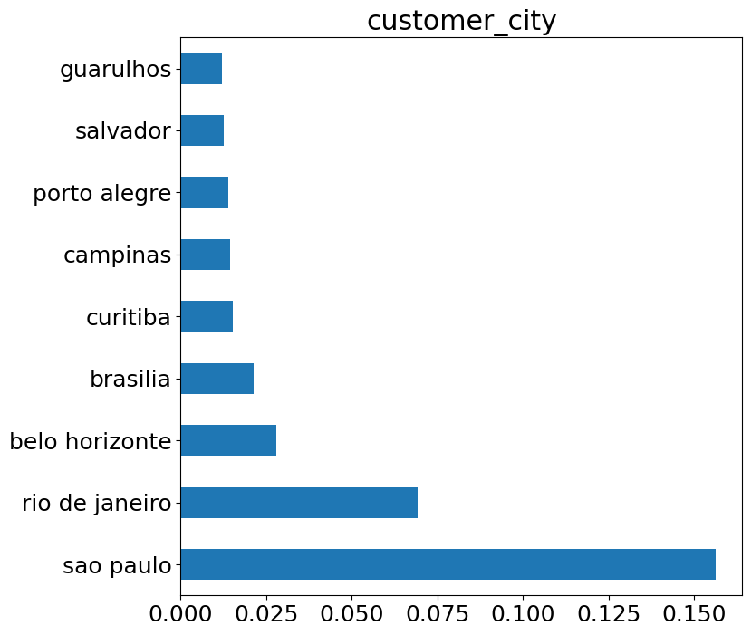

```python
distribution_variables_object4(df_customers['customer_city'],8,8,'customer_city',0.01)
```

Les clients se trouvent majoritairement dans les villes de Sao- paulo, Rio de Janeiro et belo Horizonte

```python
federative_units = {"AC": "Acre",
                    "AL": "Alagoas",
                    "AM": "Amazonas",
                    "AP": "Amapá",
                    "BA": "Bahia",
                    "CE": "Ceará",
                    "ES": "Espírito Santo",
                    "GO": "Goiás",
                    "MA": "Maranhão",
                    "MT": "Mato Grosso",
                    "MS": "Mato Grosso do Sul",
                    "MG": "Minas Gerais",
                    "PA": "Pará",
                    "PB": "Paraïba",
                    "PE": "Pernambouc",
                    "PI": "Piauí",
                    "PR": "Paraná",
                    "RJ": "Rio de Janeiro",
                    "RO": "Rondônia",
                    "RN": "Rio Grande do Norte",
                    "RS": "Rio Grande do Sul ",
                    "RR": "Roraima",
                    "SC": "Santa Catarina",
                    "SP": "São Paulo",
                    "SE": "Sergipe",
                    "TO": "Tocantins ",
                    "DF": "District fédéral"}
```

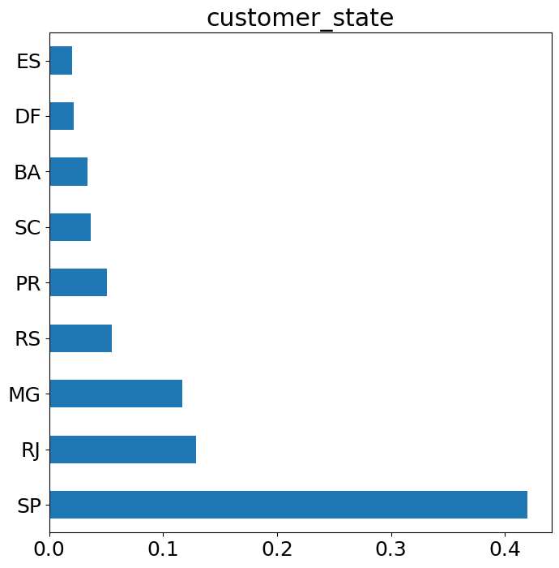

```python
distribution_variables_object4(df_customers['customer_state'],8,8,'customer_state',0.01)
```

Les clients se trouvent majoritairement dans les Etats de Sao- paulo, Rio de Janeiro et Minas Gerais

## 2) olist_geolocation_dataset.csv

```python
df_geolocation.head()
```

|  | geolocation_zip_code_prefix | geolocation_lat | geolocation_lng | geolocation_city | geolocation_state |
| --- | --- | --- | --- | --- | --- |
| 0 | 1037 | -23.545621 | -46.639292 | sao paulo | SP |
| 1 | 1046 | -23.546081 | -46.644820 | sao paulo | SP |
| 2 | 1046 | -23.546129 | -46.642951 | sao paulo | SP |
| 3 | 1041 | -23.544392 | -46.639499 | sao paulo | SP |
| 4 | 1035 | -23.541578 | -46.641607 | sao paulo | SP |

```python
df_geolocation.info()
```

```
<class 'pandas.core.frame.DataFrame'>
RangeIndex: 1000163 entries, 0 to 1000162
Data columns (total 5 columns):
 #   Column                       Non-Null Count    Dtype
---  ------                       --------------    -----
 0   geolocation_zip_code_prefix  1000163 non-null  int64
 1   geolocation_lat              1000163 non-null  float64
 2   geolocation_lng              1000163 non-null  float64
 3   geolocation_city             1000163 non-null  object
 4   geolocation_state            1000163 non-null  object
dtypes: float64(2), int64(1), object(2)
memory usage: 38.2+ MB
```

### Recherche de doublons

```python
df_geolocation[df_geolocation.duplicated(keep=False)==True]
```

|  | geolocation_zip_code_prefix | geolocation_lat | geolocation_lng | geolocation_city | geolocation_state |
| --- | --- | --- | --- | --- | --- |
| 0 | 1037 | -23.545621 | -46.639292 | sao paulo | SP |
| 1 | 1046 | -23.546081 | -46.644820 | sao paulo | SP |
| 2 | 1046 | -23.546129 | -46.642951 | sao paulo | SP |
| 6 | 1047 | -23.546273 | -46.641225 | sao paulo | SP |
| 7 | 1013 | -23.546923 | -46.634264 | sao paulo | SP |
| ... | ... | ... | ... | ... | ... |
| 1000153 | 99970 | -28.343273 | -51.873734 | ciriaco | RS |
| 1000154 | 99950 | -28.070493 | -52.011342 | tapejara | RS |
| 1000159 | 99900 | -27.877125 | -52.224882 | getulio vargas | RS |
| 1000160 | 99950 | -28.071855 | -52.014716 | tapejara | RS |
| 1000162 | 99950 | -28.070104 | -52.018658 | tapejara | RS |

390005 rows × 5 columns

```python
df_geolocation=df_geolocation.drop_duplicates()
```

```python
df_geolocation['geolocation_zip_code_prefix'].nunique()
```

```
19015
```

```python
df_geolocation['geolocation_city'].nunique()
```

```
8011
```

### Regroupement en fonction du zipcode

Par souci de simplification nous utiliserons une moyenne des coordonnées géographiques pour chaque zipcode

```python
df_geoloc=df_geolocation.groupby('geolocation_zip_code_prefix',as_index=False).agg({'geolocation_lat':'mean','geolocation_lng':'mean'})
df_geoloc
```

|  | geolocation_zip_code_prefix | geolocation_lat | geolocation_lng |
| --- | --- | --- | --- |
| 0 | 1001 | -23.550227 | -46.634039 |
| 1 | 1002 | -23.547657 | -46.634991 |
| 2 | 1003 | -23.549000 | -46.635582 |
| 3 | 1004 | -23.549829 | -46.634792 |
| 4 | 1005 | -23.549547 | -46.636406 |
| ... | ... | ... | ... |
| 19010 | 99960 | -27.953722 | -52.025511 |
| 19011 | 99965 | -28.183372 | -52.039850 |
| 19012 | 99970 | -28.343920 | -51.874988 |
| 19013 | 99980 | -28.389500 | -51.843122 |
| 19014 | 99990 | -28.329595 | -51.769362 |

19015 rows × 3 columns

## 3) olist_orders_dataset.csv

```python
df_orders.head()
```

|  | order_id | customer_id | order_status | order_purchase_timestamp | order_approved_at | order_delivered_carrier_date | order_delivered_customer_date | order_estimated_delivery_date |
| --- | --- | --- | --- | --- | --- | --- | --- | --- |
| 0 | e481f51cbdc54678b7cc49136f2d6af7 | 9ef432eb6251297304e76186b10a928d | delivered | 2017-10-02 10:56:33 | 2017-10-02 11:07:15 | 2017-10-04 19:55:00 | 2017-10-10 21:25:13 | 2017-10-18 00:00:00 |
| 1 | 53cdb2fc8bc7dce0b6741e2150273451 | b0830fb4747a6c6d20dea0b8c802d7ef | delivered | 2018-07-24 20:41:37 | 2018-07-26 03:24:27 | 2018-07-26 14:31:00 | 2018-08-07 15:27:45 | 2018-08-13 00:00:00 |
| 2 | 47770eb9100c2d0c44946d9cf07ec65d | 41ce2a54c0b03bf3443c3d931a367089 | delivered | 2018-08-08 08:38:49 | 2018-08-08 08:55:23 | 2018-08-08 13:50:00 | 2018-08-17 18:06:29 | 2018-09-04 00:00:00 |
| 3 | 949d5b44dbf5de918fe9c16f97b45f8a | f88197465ea7920adcdbec7375364d82 | delivered | 2017-11-18 19:28:06 | 2017-11-18 19:45:59 | 2017-11-22 13:39:59 | 2017-12-02 00:28:42 | 2017-12-15 00:00:00 |
| 4 | ad21c59c0840e6cb83a9ceb5573f8159 | 8ab97904e6daea8866dbdbc4fb7aad2c | delivered | 2018-02-13 21:18:39 | 2018-02-13 22:20:29 | 2018-02-14 19:46:34 | 2018-02-16 18:17:02 | 2018-02-26 00:00:00 |

### Sélection des commandes livrées

```python
df_orders=df_orders[df_orders['order_status']=='delivered']
```

```python
df_orders.info()
```

```
<class 'pandas.core.frame.DataFrame'>
Int64Index: 96478 entries, 0 to 99440
Data columns (total 8 columns):
 #   Column                         Non-Null Count  Dtype
---  ------                         --------------  -----
 0   order_id                       96478 non-null  object
 1   customer_id                    96478 non-null  object
 2   order_status                   96478 non-null  object
 3   order_purchase_timestamp       96478 non-null  object
 4   order_approved_at              96464 non-null  object
 5   order_delivered_carrier_date   96476 non-null  object
 6   order_delivered_customer_date  96470 non-null  object
 7   order_estimated_delivery_date  96478 non-null  object
dtypes: object(8)
memory usage: 6.6+ MB
```

### Valeurs manquantes

```python
# On choisit de supprimer les valeurs manquantes vu leur faible nombre
df_orders= df_orders.dropna(subset=['order_approved_at',
                                    'order_delivered_carrier_date',
                                    'order_delivered_customer_date'])
df_orders.info()
```

```
<class 'pandas.core.frame.DataFrame'>
Int64Index: 96455 entries, 0 to 99440
Data columns (total 8 columns):
 #   Column                         Non-Null Count  Dtype
---  ------                         --------------  -----
 0   order_id                       96455 non-null  object
 1   customer_id                    96455 non-null  object
 2   order_status                   96455 non-null  object
 3   order_purchase_timestamp       96455 non-null  object
 4   order_approved_at              96455 non-null  object
 5   order_delivered_carrier_date   96455 non-null  object
 6   order_delivered_customer_date  96455 non-null  object
 7   order_estimated_delivery_date  96455 non-null  object
dtypes: object(8)
memory usage: 6.6+ MB
```

### Recherche de doublons

```python
df_orders[df_orders.duplicated(keep=False)==True]
```

|  | order_id | customer_id | order_status | order_purchase_timestamp | order_approved_at | order_delivered_carrier_date | order_delivered_customer_date | order_estimated_delivery_date |
| --- | --- | --- | --- | --- | --- | --- | --- | --- |

```python
# Période d'étude
df_orders['order_purchase_timestamp'].min(),df_orders['order_purchase_timestamp'].max()
```

```
('2016-09-15 12:16:38', '2018-08-29 15:00:37')
```

```python
df_orders.describe()
```

|  | order_id | customer_id | order_status | order_purchase_timestamp | order_approved_at | order_delivered_carrier_date | order_delivered_customer_date | order_estimated_delivery_date |
| --- | --- | --- | --- | --- | --- | --- | --- | --- |
| count | 96455 | 96455 | 96455 | 96455 | 96455 | 96455 | 96455 | 96455 |
| unique | 96455 | 96455 | 1 | 95933 | 88266 | 80094 | 95643 | 445 |
| top | e481f51cbdc54678b7cc49136f2d6af7 | 9ef432eb6251297304e76186b10a928d | delivered | 2018-08-02 12:06:07 | 2018-02-27 04:31:10 | 2018-05-09 15:48:00 | 2018-07-24 21:36:42 | 2017-12-20 00:00:00 |
| freq | 1 | 1 | 96455 | 3 | 9 | 47 | 3 | 507 |

## 4) olist_order_items_dataset.csv

```python
df_orders_items.head()
```

|  | order_id | order_item_id | product_id | seller_id | shipping_limit_date | price | freight_value |
| --- | --- | --- | --- | --- | --- | --- | --- |
| 0 | 00010242fe8c5a6d1ba2dd792cb16214 | 1 | 4244733e06e7ecb4970a6e2683c13e61 | 48436dade18ac8b2bce089ec2a041202 | 2017-09-19 09:45:35 | 58.90 | 13.29 |
| 1 | 00018f77f2f0320c557190d7a144bdd3 | 1 | e5f2d52b802189ee658865ca93d83a8f | dd7ddc04e1b6c2c614352b383efe2d36 | 2017-05-03 11:05:13 | 239.90 | 19.93 |
| 2 | 000229ec398224ef6ca0657da4fc703e | 1 | c777355d18b72b67abbeef9df44fd0fd | 5b51032eddd242adc84c38acab88f23d | 2018-01-18 14:48:30 | 199.00 | 17.87 |
| 3 | 00024acbcdf0a6daa1e931b038114c75 | 1 | 7634da152a4610f1595efa32f14722fc | 9d7a1d34a5052409006425275ba1c2b4 | 2018-08-15 10:10:18 | 12.99 | 12.79 |
| 4 | 00042b26cf59d7ce69dfabb4e55b4fd9 | 1 | ac6c3623068f30de03045865e4e10089 | df560393f3a51e74553ab94004ba5c87 | 2017-02-13 13:57:51 | 199.90 | 18.14 |

```python
df_orders_items.describe()
```

|  | order_item_id | price | freight_value |
| --- | --- | --- | --- |
| count | 112650.000000 | 112650.000000 | 112650.000000 |
| mean | 1.197834 | 120.653739 | 19.990320 |
| std | 0.705124 | 183.633928 | 15.806405 |
| min | 1.000000 | 0.850000 | 0.000000 |
| 25% | 1.000000 | 39.900000 | 13.080000 |
| 50% | 1.000000 | 74.990000 | 16.260000 |
| 75% | 1.000000 | 134.900000 | 21.150000 |
| max | 21.000000 | 6735.000000 | 409.680000 |

```python
df_orders_items['order_item_id'].nunique()
```

```
21
```

Le nombre d'articles par commande varie de 1 à 21

```python
df_orders_items['seller_id'].nunique()
```

```
3095
```

On dénombre 3095 vendeurs différents.

```python
df_orders_items['product_id'].nunique()
```

```
32951
```

```python
df_orders_items.info()
```

```
<class 'pandas.core.frame.DataFrame'>
RangeIndex: 112650 entries, 0 to 112649
Data columns (total 7 columns):
 #   Column               Non-Null Count   Dtype
---  ------               --------------   -----
 0   order_id             112650 non-null  object
 1   order_item_id        112650 non-null  int64
 2   product_id           112650 non-null  object
 3   seller_id            112650 non-null  object
 4   shipping_limit_date  112650 non-null  object
 5   price                112650 non-null  float64
 6   freight_value        112650 non-null  float64
dtypes: float64(2), int64(1), object(4)
memory usage: 6.0+ MB
```

### Recherche de doublons

```python
df_orders_items[df_orders_items.duplicated(keep=False)==True]
```

|  | order_id | order_item_id | product_id | seller_id | shipping_limit_date | price | freight_value |
| --- | --- | --- | --- | --- | --- | --- | --- |

## 5) olist_order_payments_dataset.csv

```python
df_order_payments.head()
```

|  | order_id | payment_sequential | payment_type | payment_installments | payment_value |
| --- | --- | --- | --- | --- | --- |
| 0 | b81ef226f3fe1789b1e8b2acac839d17 | 1 | credit_card | 8 | 99.33 |
| 1 | a9810da82917af2d9aefd1278f1dcfa0 | 1 | credit_card | 1 | 24.39 |
| 2 | 25e8ea4e93396b6fa0d3dd708e76c1bd | 1 | credit_card | 1 | 65.71 |
| 3 | ba78997921bbcdc1373bb41e913ab953 | 1 | credit_card | 8 | 107.78 |
| 4 | 42fdf880ba16b47b59251dd489d4441a | 1 | credit_card | 2 | 128.45 |

```python
df_order_payments.info()
```

```
<class 'pandas.core.frame.DataFrame'>
RangeIndex: 103886 entries, 0 to 103885
Data columns (total 5 columns):
 #   Column                Non-Null Count   Dtype
---  ------                --------------   -----
 0   order_id              103886 non-null  object
 1   payment_sequential    103886 non-null  int64
 2   payment_type          103886 non-null  object
 3   payment_installments  103886 non-null  int64
 4   payment_value         103886 non-null  float64
dtypes: float64(1), int64(2), object(2)
memory usage: 4.0+ MB
```

### Recherche de doublons

```python
df_order_payments[df_order_payments.duplicated(keep=False)==True]
```

|  | order_id | payment_sequential | payment_type | payment_installments | payment_value |
| --- | --- | --- | --- | --- | --- |

### Créations de variables type de paiements

```python
group_payments = df_order_payments.groupby("order_id").agg(
    {"payment_sequential": 'count',
     "payment_installments": 'sum'})
group_payments = group_payments.rename(columns={
    "payment_sequential": "nb_payment_sequential",
    "payment_installments": "sum_payment_installments"})
df_order_payments = pd.merge(df_order_payments, group_payments,
                       how="left",
                       on="order_id")

df_order_payments.head(3)
```

|  | order_id | payment_sequential | payment_type | payment_installments | payment_value | nb_payment_sequential | sum_payment_installments |
| --- | --- | --- | --- | --- | --- | --- | --- |
| 0 | b81ef226f3fe1789b1e8b2acac839d17 | 1 | credit_card | 8 | 99.33 | 1 | 8 |
| 1 | a9810da82917af2d9aefd1278f1dcfa0 | 1 | credit_card | 1 | 24.39 | 1 | 1 |
| 2 | 25e8ea4e93396b6fa0d3dd708e76c1bd | 1 | credit_card | 1 | 65.71 | 1 | 1 |

## 6) olist_order_reviews_dataset.csv

```python
df_order_reviews.head()
```

|  | review_id | order_id | review_score | review_comment_title | review_comment_message | review_creation_date | review_answer_timestamp |
| --- | --- | --- | --- | --- | --- | --- | --- |
| 0 | 7bc2406110b926393aa56f80a40eba40 | 73fc7af87114b39712e6da79b0a377eb | 4 | NaN | NaN | 2018-01-18 00:00:00 | 2018-01-18 21:46:59 |
| 1 | 80e641a11e56f04c1ad469d5645fdfde | a548910a1c6147796b98fdf73dbeba33 | 5 | NaN | NaN | 2018-03-10 00:00:00 | 2018-03-11 03:05:13 |
| 2 | 228ce5500dc1d8e020d8d1322874b6f0 | f9e4b658b201a9f2ecdecbb34bed034b | 5 | NaN | NaN | 2018-02-17 00:00:00 | 2018-02-18 14:36:24 |
| 3 | e64fb393e7b32834bb789ff8bb30750e | 658677c97b385a9be170737859d3511b | 5 | NaN | Recebi bem antes do prazo estipulado. | 2017-04-21 00:00:00 | 2017-04-21 22:02:06 |
| 4 | f7c4243c7fe1938f181bec41a392bdeb | 8e6bfb81e283fa7e4f11123a3fb894f1 | 5 | NaN | Parabéns lojas lannister adorei comprar pela I... | 2018-03-01 00:00:00 | 2018-03-02 10:26:53 |

```python
df_order_reviews.info()
```

```
<class 'pandas.core.frame.DataFrame'>
RangeIndex: 99224 entries, 0 to 99223
Data columns (total 7 columns):
 #   Column                   Non-Null Count  Dtype
---  ------                   --------------  -----
 0   review_id                99224 non-null  object
 1   order_id                 99224 non-null  object
 2   review_score             99224 non-null  int64
 3   review_comment_title     11568 non-null  object
 4   review_comment_message   40977 non-null  object
 5   review_creation_date     99224 non-null  object
 6   review_answer_timestamp  99224 non-null  object
dtypes: int64(1), object(6)
memory usage: 5.3+ MB
```

### Recherche de doublons

```python
df_order_reviews[df_order_reviews.duplicated(keep=False)==True]
```

|  | review_id | order_id | review_score | review_comment_title | review_comment_message | review_creation_date | review_answer_timestamp |
| --- | --- | --- | --- | --- | --- | --- | --- |

### Valeurs manquantes

```python
df_review= df_order_reviews.dropna(inplace= False)
df_review
```

|  | review_id | order_id | review_score | review_comment_title | review_comment_message | review_creation_date | review_answer_timestamp |
| --- | --- | --- | --- | --- | --- | --- | --- |
| 9 | 8670d52e15e00043ae7de4c01cc2fe06 | b9bf720beb4ab3728760088589c62129 | 4 | recomendo | aparelho eficiente. no site a marca do aparelh... | 2018-05-22 00:00:00 | 2018-05-23 16:45:47 |
| 15 | 3948b09f7c818e2d86c9a546758b2335 | e51478e7e277a83743b6f9991dbfa3fb | 5 | Super recomendo | Vendedor confiável, produto ok e entrega antes... | 2018-05-23 00:00:00 | 2018-05-24 03:00:01 |
| 19 | 373cbeecea8286a2b66c97b1b157ec46 | 583174fbe37d3d5f0d6661be3aad1786 | 1 | Não chegou meu produto | Péssimo | 2018-08-15 00:00:00 | 2018-08-15 04:10:37 |
| 22 | d21bbc789670eab777d27372ab9094cc | 4fc44d78867142c627497b60a7e0228a | 5 | Ótimo | Loja nota 10 | 2018-07-10 00:00:00 | 2018-07-11 14:10:25 |
| 34 | c92cdd7dd544a01aa35137f901669cdf | 37e7875cdce5a9e5b3a692971f370151 | 4 | Muito bom. | Recebi exatamente o que esperava. As demais en... | 2018-06-07 00:00:00 | 2018-06-09 18:44:02 |
| ... | ... | ... | ... | ... | ... | ... | ... |
| 99187 | 47e0954e156dac6512c25c6d2ecc1c66 | 16cbf959cfdb88c47ee2a29303547ec2 | 5 | Nota máxima! | Muito obrigado,\r\n\r\nExcelente atendimento,b... | 2018-05-22 00:00:00 | 2018-05-23 00:51:43 |
| 99192 | 0e7bc73fde6782891898ea71443f9904 | bd78f91afbb1ecbc6124974c5e813043 | 4 | 👍 | Aprovado! | 2018-07-04 00:00:00 | 2018-07-05 00:25:13 |
| 99196 | 58be140ccdc12e8908ff7fd2ba5c7cb0 | 0ebf8e35b9807ee2d717922d5663ccdb | 5 | muito bom produto | Ficamos muito satisfeitos com o produto, atend... | 2018-06-30 00:00:00 | 2018-07-02 23:09:35 |
| 99197 | 51de4e06a6b701cb2be47ea0e689437b | b7467ae483dbe956fe9acdf0b1e6e3f4 | 3 | Não foi entregue o pedido | Bom dia \r\nDas 6 unidades compradas só recebi... | 2018-06-05 00:00:00 | 2018-06-06 10:52:19 |
| 99200 | 2ee221b28e5b6fceffac59487ed39348 | f2d12dd37eaef72ed7b1186b2edefbcd | 2 | Foto enganosa | Foto muito diferente principalmente a graninha... | 2018-03-28 00:00:00 | 2018-05-25 01:23:26 |

9839 rows × 7 columns

### Création d'une variable satisfaction

```python
#Création d'une variable satisfaction

encoded_class = { 1 : 'Not Satisfied',
                  2 : 'Not Satisfied',
                  3 : 'Not Satisfied',
                  4 : 'Satisfied',
                  5 : 'Satisfied'}

df_order_reviews['Satisfaction'] = df_order_reviews['review_score'].map(encoded_class)
```

```python
encoded_class2 = { 'Not Satisfied': -1,
                  'Satisfied': 1,
                  }
df_order_reviews['Satisfaction_num'] = df_order_reviews['Satisfaction'].map(encoded_class2)
```

```python
df_order_reviews.head()
```

|  | review_id | order_id | review_score | review_comment_title | review_comment_message | review_creation_date | review_answer_timestamp | Satisfaction | Satisfaction_num |
| --- | --- | --- | --- | --- | --- | --- | --- | --- | --- |
| 0 | 7bc2406110b926393aa56f80a40eba40 | 73fc7af87114b39712e6da79b0a377eb | 4 | NaN | NaN | 2018-01-18 00:00:00 | 2018-01-18 21:46:59 | Satisfied | 1 |
| 1 | 80e641a11e56f04c1ad469d5645fdfde | a548910a1c6147796b98fdf73dbeba33 | 5 | NaN | NaN | 2018-03-10 00:00:00 | 2018-03-11 03:05:13 | Satisfied | 1 |
| 2 | 228ce5500dc1d8e020d8d1322874b6f0 | f9e4b658b201a9f2ecdecbb34bed034b | 5 | NaN | NaN | 2018-02-17 00:00:00 | 2018-02-18 14:36:24 | Satisfied | 1 |
| 3 | e64fb393e7b32834bb789ff8bb30750e | 658677c97b385a9be170737859d3511b | 5 | NaN | Recebi bem antes do prazo estipulado. | 2017-04-21 00:00:00 | 2017-04-21 22:02:06 | Satisfied | 1 |
| 4 | f7c4243c7fe1938f181bec41a392bdeb | 8e6bfb81e283fa7e4f11123a3fb894f1 | 5 | NaN | Parabéns lojas lannister adorei comprar pela I... | 2018-03-01 00:00:00 | 2018-03-02 10:26:53 | Satisfied | 1 |

```python
# Create a separate DataFrame to check reasons of non satisfaction
non_satisfied = df_order_reviews[df_order_reviews['Satisfaction'] == 'Not Satisfied']

# Reset index
non_satisfied.reset_index(inplace= True, drop= True)
```

## 7) olist_products_dataset.csv

```python
df_products.head()
```

|  | product_id | product_category_name | product_name_lenght | product_description_lenght | product_photos_qty | product_weight_g | product_length_cm | product_height_cm | product_width_cm |
| --- | --- | --- | --- | --- | --- | --- | --- | --- | --- |
| 0 | 1e9e8ef04dbcff4541ed26657ea517e5 | perfumaria | 40.0 | 287.0 | 1.0 | 225.0 | 16.0 | 10.0 | 14.0 |
| 1 | 3aa071139cb16b67ca9e5dea641aaa2f | artes | 44.0 | 276.0 | 1.0 | 1000.0 | 30.0 | 18.0 | 20.0 |
| 2 | 96bd76ec8810374ed1b65e291975717f | esporte_lazer | 46.0 | 250.0 | 1.0 | 154.0 | 18.0 | 9.0 | 15.0 |
| 3 | cef67bcfe19066a932b7673e239eb23d | bebes | 27.0 | 261.0 | 1.0 | 371.0 | 26.0 | 4.0 | 26.0 |
| 4 | 9dc1a7de274444849c219cff195d0b71 | utilidades_domesticas | 37.0 | 402.0 | 4.0 | 625.0 | 20.0 | 17.0 | 13.0 |

```python
df_products.info()
```

```
<class 'pandas.core.frame.DataFrame'>
RangeIndex: 32951 entries, 0 to 32950
Data columns (total 9 columns):
 #   Column                      Non-Null Count  Dtype
---  ------                      --------------  -----
 0   product_id                  32951 non-null  object
 1   product_category_name       32341 non-null  object
 2   product_name_lenght         32341 non-null  float64
 3   product_description_lenght  32341 non-null  float64
 4   product_photos_qty          32341 non-null  float64
 5   product_weight_g            32949 non-null  float64
 6   product_length_cm           32949 non-null  float64
 7   product_height_cm           32949 non-null  float64
 8   product_width_cm            32949 non-null  float64
dtypes: float64(7), object(2)
memory usage: 2.3+ MB
```

```python
df_products[df_products.duplicated(keep=False)==True]
```

|  | product_id | product_category_name | product_name_lenght | product_description_lenght | product_photos_qty | product_weight_g | product_length_cm | product_height_cm | product_width_cm |
| --- | --- | --- | --- | --- | --- | --- | --- | --- | --- |

## 8) olist_sellers_dataset.csv

```python
df_sellers.head()
```

|  | seller_id | seller_zip_code_prefix | seller_city | seller_state |
| --- | --- | --- | --- | --- |
| 0 | 3442f8959a84dea7ee197c632cb2df15 | 13023 | campinas | SP |
| 1 | d1b65fc7debc3361ea86b5f14c68d2e2 | 13844 | mogi guacu | SP |
| 2 | ce3ad9de960102d0677a81f5d0bb7b2d | 20031 | rio de janeiro | RJ |
| 3 | c0f3eea2e14555b6faeea3dd58c1b1c3 | 4195 | sao paulo | SP |
| 4 | 51a04a8a6bdcb23deccc82b0b80742cf | 12914 | braganca paulista | SP |

```python
df_sellers.info()
```

```
<class 'pandas.core.frame.DataFrame'>
RangeIndex: 3095 entries, 0 to 3094
Data columns (total 4 columns):
 #   Column                  Non-Null Count  Dtype
---  ------                  --------------  -----
 0   seller_id               3095 non-null   object
 1   seller_zip_code_prefix  3095 non-null   int64
 2   seller_city             3095 non-null   object
 3   seller_state            3095 non-null   object
dtypes: int64(1), object(3)
memory usage: 96.8+ KB
```

```python
df_sellers[df_sellers.duplicated(keep=False)==True]
```

|  | seller_id | seller_zip_code_prefix | seller_city | seller_state |
| --- | --- | --- | --- | --- |

## 9) product_category_name_translation.csv

```python
df_product_cat.head()
```

|  | product_category_name | product_category_name_english |
| --- | --- | --- |
| 0 | beleza_saude | health_beauty |
| 1 | informatica_acessorios | computers_accessories |
| 2 | automotivo | auto |
| 3 | cama_mesa_banho | bed_bath_table |
| 4 | moveis_decoracao | furniture_decor |

```python
df_product_cat.info()
```

```
<class 'pandas.core.frame.DataFrame'>
RangeIndex: 71 entries, 0 to 70
Data columns (total 2 columns):
 #   Column                         Non-Null Count  Dtype
---  ------                         --------------  -----
 0   product_category_name          71 non-null     object
 1   product_category_name_english  71 non-null     object
dtypes: object(2)
memory usage: 1.2+ KB
```

# Synthèse et sauvegarde

## 1) Synthèse et exploration du dataset final

### Création du dataset final

```python
df_synt= df_orders.merge(df_customers, on='customer_id', how='left')
df_synt= df_synt.merge(df_order_reviews, on= 'order_id', how='left')
df_synt= df_synt.merge(df_orders_items, on= 'order_id', how='left')
df_synt= df_synt.merge(df_products, on= 'product_id', how='left')
df_synt= df_synt.merge(df_order_payments, on= 'order_id', how='left')
df_synt= df_synt.merge(df_sellers, on= 'seller_id', how='left')
df_synt= df_synt.merge(df_product_cat, on= 'product_category_name', how='left')
df_synt= df_synt.merge(df_geoloc, left_on= 'customer_zip_code_prefix',right_on='geolocation_zip_code_prefix', how='left')
df_synt= df_synt.merge(df_geoloc, left_on= 'seller_zip_code_prefix',right_on='geolocation_zip_code_prefix', how='left')
#suppression de la colonne 'order status'
df_synt=df_synt.drop(columns=['order_status'])
pd.set_option('display.max_columns', None)
df_synt.head()
```

|  | order_id | customer_id | order_purchase_timestamp | order_approved_at | order_delivered_carrier_date | order_delivered_customer_date | order_estimated_delivery_date | customer_unique_id | customer_zip_code_prefix | customer_city | customer_state | review_id | review_score | review_comment_title | review_comment_message | review_creation_date | review_answer_timestamp | Satisfaction | Satisfaction_num | order_item_id | product_id | seller_id | shipping_limit_date | price | freight_value | product_category_name | product_name_lenght | product_description_lenght | product_photos_qty | … |
| --- | --- | --- | --- | --- | --- | --- | --- | --- | --- | --- | --- | --- | --- | --- | --- | --- | --- | --- | --- | --- | --- | --- | --- | --- | --- | --- | --- | --- | --- | --- |
| 0 | e481f51cbdc54678b7cc49136f2d6af7 | 9ef432eb6251297304e76186b10a928d | 2017-10-02 10:56:33 | 2017-10-02 11:07:15 | 2017-10-04 19:55:00 | 2017-10-10 21:25:13 | 2017-10-18 00:00:00 | 7c396fd4830fd04220f754e42b4e5bff | 3149 | sao paulo | SP | a54f0611adc9ed256b57ede6b6eb5114 | 4.0 | NaN | Não testei o produto ainda, mas ele veio corre... | 2017-10-11 00:00:00 | 2017-10-12 03:43:48 | Satisfied | 1.0 | 1 | 87285b34884572647811a353c7ac498a | 3504c0cb71d7fa48d967e0e4c94d59d9 | 2017-10-06 11:07:15 | 29.99 | 8.72 | utilidades_domesticas | 40.0 | 268.0 | 4.0 | … |
| 1 | e481f51cbdc54678b7cc49136f2d6af7 | 9ef432eb6251297304e76186b10a928d | 2017-10-02 10:56:33 | 2017-10-02 11:07:15 | 2017-10-04 19:55:00 | 2017-10-10 21:25:13 | 2017-10-18 00:00:00 | 7c396fd4830fd04220f754e42b4e5bff | 3149 | sao paulo | SP | a54f0611adc9ed256b57ede6b6eb5114 | 4.0 | NaN | Não testei o produto ainda, mas ele veio corre... | 2017-10-11 00:00:00 | 2017-10-12 03:43:48 | Satisfied | 1.0 | 1 | 87285b34884572647811a353c7ac498a | 3504c0cb71d7fa48d967e0e4c94d59d9 | 2017-10-06 11:07:15 | 29.99 | 8.72 | utilidades_domesticas | 40.0 | 268.0 | 4.0 | … |
| 2 | e481f51cbdc54678b7cc49136f2d6af7 | 9ef432eb6251297304e76186b10a928d | 2017-10-02 10:56:33 | 2017-10-02 11:07:15 | 2017-10-04 19:55:00 | 2017-10-10 21:25:13 | 2017-10-18 00:00:00 | 7c396fd4830fd04220f754e42b4e5bff | 3149 | sao paulo | SP | a54f0611adc9ed256b57ede6b6eb5114 | 4.0 | NaN | Não testei o produto ainda, mas ele veio corre... | 2017-10-11 00:00:00 | 2017-10-12 03:43:48 | Satisfied | 1.0 | 1 | 87285b34884572647811a353c7ac498a | 3504c0cb71d7fa48d967e0e4c94d59d9 | 2017-10-06 11:07:15 | 29.99 | 8.72 | utilidades_domesticas | 40.0 | 268.0 | 4.0 | … |
| 3 | 53cdb2fc8bc7dce0b6741e2150273451 | b0830fb4747a6c6d20dea0b8c802d7ef | 2018-07-24 20:41:37 | 2018-07-26 03:24:27 | 2018-07-26 14:31:00 | 2018-08-07 15:27:45 | 2018-08-13 00:00:00 | af07308b275d755c9edb36a90c618231 | 47813 | barreiras | BA | 8d5266042046a06655c8db133d120ba5 | 4.0 | Muito boa a loja | Muito bom o produto. | 2018-08-08 00:00:00 | 2018-08-08 18:37:50 | Satisfied | 1.0 | 1 | 595fac2a385ac33a80bd5114aec74eb8 | 289cdb325fb7e7f891c38608bf9e0962 | 2018-07-30 03:24:27 | 118.70 | 22.76 | perfumaria | 29.0 | 178.0 | 1.0 | … |
| 4 | 47770eb9100c2d0c44946d9cf07ec65d | 41ce2a54c0b03bf3443c3d931a367089 | 2018-08-08 08:38:49 | 2018-08-08 08:55:23 | 2018-08-08 13:50:00 | 2018-08-17 18:06:29 | 2018-09-04 00:00:00 | 3a653a41f6f9fc3d2a113cf8398680e8 | 75265 | vianopolis | GO | e73b67b67587f7644d5bd1a52deb1b01 | 5.0 | NaN | NaN | 2018-08-18 00:00:00 | 2018-08-22 19:07:58 | Satisfied | 1.0 | 1 | aa4383b373c6aca5d8797843e5594415 | 4869f7a5dfa277a7dca6462dcf3b52b2 | 2018-08-13 08:55:23 | 159.90 | 19.22 | automotivo | 46.0 | 232.0 | 1.0 | … |

```python
df_synt.info()
```

```
<class 'pandas.core.frame.DataFrame'>
Int64Index: 115699 entries, 0 to 115698
Data columns (total 49 columns):
 #   Column                         Non-Null Count   Dtype
---  ------                         --------------   -----
 0   order_id                       115699 non-null  object
 1   customer_id                    115699 non-null  object
 2   order_purchase_timestamp       115699 non-null  object
 3   order_approved_at              115699 non-null  object
 4   order_delivered_carrier_date   115699 non-null  object
 5   order_delivered_customer_date  115699 non-null  object
 6   order_estimated_delivery_date  115699 non-null  object
 7   customer_unique_id             115699 non-null  object
 8   customer_zip_code_prefix       115699 non-null  int64
 9   customer_city                  115699 non-null  object
```

[output cut: 41 more lines]

```python
def missing_values_barplot(dataset):
    missing_values = dataset.isnull().sum()
    plt.figure(figsize=(20,10))
    plt.title("Pourcentages de valeurs manquantes par variable")
    plt.xlabel("Variables")
    plt.ylabel("Pourcentages de valeurs manquantes")
    plt.bar(np.arange(missing_values.index.size),
            100 * missing_values / dataset.index.size,
            color='b', width=1, edgecolor='black')
    plt.xticks(np.arange(missing_values.index.size),
               missing_values.index,
               rotation=90)
```

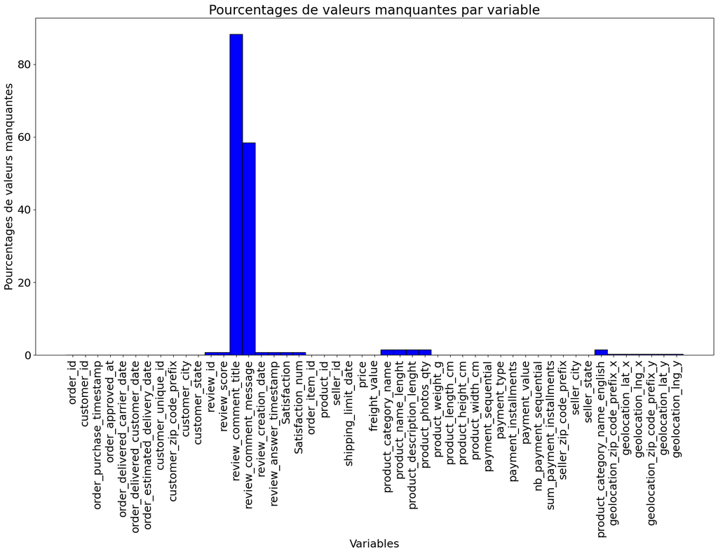

```python
missing_values_barplot(df_synt)
```

## 2) Selection et création de variables

### Création d'une variable distance client-vendeur

```python
# Suppression des valeurs manquantes des variables de géolocalisation
df_synt=df_synt.dropna(subset=['geolocation_zip_code_prefix_y'])
```

```python
def haversine_np(lon1, lat1, lon2, lat2):
    lat1 = lat1 * math.pi / 180.0
    lat2 = lat2 * math.pi / 180.0
    dLat = (lat2 - lat1)
    dLon = (lon2 - lon1) * math.pi / 180.0
    a =dLat.apply(lambda x: pow(np.sin(x / 2), 2))
    b =dLon.apply(lambda x: pow(np.sin(x / 2), 2))
    c =a+b*lat1.apply(lambda x: np.cos(x)) * lat2.apply(lambda x: np.cos(x))
    r = 6371
    d = 2 * c.apply(lambda x: np.arcsin(np.sqrt(x)))
    e=r*d
    return e
```

```python
df_synt['distance_client_vendeur']= haversine_np(df_synt['geolocation_lng_x'],
                                                 df_synt['geolocation_lat_x'],
                                                 df_synt['geolocation_lng_y'],
                                                 df_synt['geolocation_lat_y'])
```

```python
df_synt.describe()
```

|  | customer_zip_code_prefix | review_score | Satisfaction_num | order_item_id | price | freight_value | product_name_lenght | product_description_lenght | product_photos_qty | product_weight_g | product_length_cm | product_height_cm | product_width_cm | payment_sequential | payment_installments | payment_value | nb_payment_sequential | sum_payment_installments | seller_zip_code_prefix | geolocation_zip_code_prefix_x | geolocation_lat_x | geolocation_lng_x | geolocation_zip_code_prefix_y | geolocation_lat_y | geolocation_lng_y | distance_client_vendeur |
| --- | --- | --- | --- | --- | --- | --- | --- | --- | --- | --- | --- | --- | --- | --- | --- | --- | --- | --- | --- | --- | --- | --- | --- | --- | --- | --- |
| count | 115438.000000 | 114577.000000 | 114577.000000 | 115438.000000 | 115438.000000 | 115438.000000 | 113802.000000 | 113802.000000 | 113802.000000 | 115418.000000 | 115418.000000 | 115418.00000 | 115418.000000 | 115435.000000 | 115435.000000 | 115435.000000 | 115435.000000 | 115435.000000 | 115438.000000 | 115136.000000 | 115136.000000 | 115136.000000 | 115438.000000 | 115438.000000 | 115438.000000 | 115136.000000 |
| mean | 35078.589607 | 4.080383 | 0.535701 | 1.197127 | 119.950667 | 19.980373 | 48.789810 | 784.825117 | 2.201446 | 2103.019330 | 30.227590 | 16.59599 | 23.051482 | 1.091428 | 2.939663 | 171.867364 | 1.181297 | 3.170269 | 24453.703139 | 35003.083041 | -21.238431 | -46.200433 | 24453.703139 | -22.794985 | -47.240162 | 596.596852 |
| std | 29855.963426 | 1.347784 | 0.844412 | 0.701706 | 182.844313 | 15.729899 | 10.018721 | 651.052220 | 1.713397 | 3765.942741 | 16.119241 | 13.42805 | 11.705890 | 0.687528 | 2.775351 | 265.910464 | 1.147694 | 2.968746 | 27587.358469 | 29842.725124 | 5.558420 | 4.039715 | 27587.358469 | 2.698245 | 2.340294 | 587.973360 |
| min | 1003.000000 | 1.000000 | -1.000000 | 1.000000 | 0.850000 | 0.000000 | 5.000000 | 4.000000 | 1.000000 | 0.000000 | 7.000000 | 2.00000 | 6.000000 | 1.000000 | 0.000000 | 0.000000 | 1.000000 | 0.000000 | 1001.000000 | 1003.000000 | -33.689890 | -72.668821 | 1001.000000 | -32.075303 | -63.893789 | 0.000000 |
| 25% | 11250.000000 | 4.000000 | 1.000000 | 1.000000 | 39.900000 | 13.070000 | 42.000000 | 345.000000 | 1.000000 | 300.000000 | 18.000000 | 8.00000 | 15.000000 | 1.000000 | 1.000000 | 60.740000 | 1.000000 | 1.000000 | 6440.000000 | 11095.000000 | -23.590473 | -48.109939 | 6440.000000 | -23.607822 | -48.829541 | 188.369670 |
| 50% | 24320.000000 | 5.000000 | 1.000000 | 1.000000 | 74.900000 | 16.270000 | 52.000000 | 600.000000 | 1.000000 | 700.000000 | 25.000000 | 13.00000 | 20.000000 | 1.000000 | 2.000000 | 108.000000 | 1.000000 | 2.000000 | 13660.000000 | 24235.000000 | -22.927958 | -46.632099 | 13660.000000 | -23.424361 | -46.756262 | 432.249872 |
| 75% | 58806.250000 | 5.000000 | 1.000000 | 1.000000 | 132.910000 | 21.150000 | 57.000000 | 982.000000 | 3.000000 | 1800.000000 | 38.000000 | 20.00000 | 30.000000 | 1.000000 | 4.000000 | 188.950000 | 1.000000 | 4.000000 | 27482.000000 | 58382.000000 | -20.182612 | -43.634268 | 27482.000000 | -21.757225 | -46.519097 | 791.502607 |
| max | 99980.000000 | 5.000000 | 1.000000 | 21.000000 | 6735.000000 | 409.680000 | 76.000000 | 3992.000000 | 20.000000 | 40425.000000 | 105.000000 | 105.00000 | 118.000000 | 26.000000 | 24.000000 | 13664.080000 | 26.000000 | 26.000000 | 99730.000000 | 99980.000000 | 42.184003 | -8.723762 | 99730.000000 | -2.503158 | -34.855831 | 8677.917816 |

```python
# Remplacement des valeurs manquantes de la variable satisfaction_num
df_synt['Satisfaction_num']=df_synt['Satisfaction_num'].fillna(0)
```

```python
#Transformation des variables "temps en datetime"
col_time=['order_purchase_timestamp',
          'order_approved_at',
         'order_delivered_carrier_date',
          'order_delivered_customer_date',
         'order_estimated_delivery_date',
          'shipping_limit_date',
          'review_creation_date',
          'review_answer_timestamp']
for date in col_time:
    df_synt[date]= pd.to_datetime(df_synt[date])
```

```python
#Période des commandes
time_delta = int((df_synt['order_delivered_customer_date'].max()
                  - df_synt['order_delivered_customer_date']
                  .min())/np.timedelta64(1,'M'))
print("La période complète des commandes porte sur {} mois."
      .format(time_delta))
```

```
La période complète des commandes porte sur 24 mois.
```

### Creation d'une variable volume

```python
# Creation d'une variable volume
df_synt['product_vol_cm3'] = df_synt['product_length_cm'] * df_synt['product_width_cm'] * df_synt['product_height_cm']

# On supprime les variables dimensions des produits
df_synt.drop(['product_length_cm', 'product_width_cm', 'product_height_cm'], axis= 1, inplace= True)
# création de variables "durée"
df_synt['recence']=(df_synt['order_purchase_timestamp'].dt.date.max()
                    -df_synt['order_purchase_timestamp'].dt.date).dt.days
df_synt['delta_order_approved_at']= (df_synt['order_approved_at'].dt.date
                                     - df_synt['order_purchase_timestamp'].dt.date).dt.days
df_synt['delta_order_delivered_carrier_date']= (df_synt['order_delivered_carrier_date'].dt.date
                                                -df_synt['order_purchase_timestamp'].dt.date).dt.days
df_synt['delta_order_delivered_customer_date']= (df_synt['order_delivered_customer_date'].dt.date
                                                -df_synt['order_purchase_timestamp'].dt.date).dt.days
df_synt['differentiel_date_prevue']= (df_synt['order_estimated_delivery_date'].dt.date
                                     -df_synt['order_delivered_customer_date'].dt.date).dt.days
df_synt['delta_seller_to_carrier_status'] = (df_synt['shipping_limit_date'].dt.date
                                            -df_synt['order_delivered_carrier_date'].dt.date).dt.days
```

### Regroupement des catégories de produits

```python
#Classification des produits
def classify_cat(x):

    if x in ['office_furniture', 'furniture_decor',
             'furniture_living_room', 'kitchen_dining_laundry_garden_furniture',
             'bed_bath_table', 'home_comfort', 'home_comfort_2',
             'home_construction', 'garden_tools', 'furniture_bedroom',
             'furniture_mattress_and_upholstery']:
        return 'Furniture'

    elif x in ['auto', 'computers_accessories',
               'musical_instruments', 'consoles_games',
               'watches_gifts', 'air_conditioning',
               'telephony', 'electronics',
               'fixed_telephony', 'tablets_printing_image',
               'computers', 'small_appliances_home_oven_and_coffee',
               'small_appliances', 'audio', 'signaling_and_security', 'security_and_services']:
        return 'Electronics'

    elif x in ['fashio_female_clothing', 'fashion_male_clothing', 'fashion_bags_accessories',
               'fashion_shoes', 'fashion_sport', 'fashion_underwear_beach',
               'fashion_childrens_clothes', 'baby', 'cool_stuff', ]:
        return 'Fashion'

    elif x in ['housewares', 'home_confort', 'home_appliances',
               'home_appliances_2', 'flowers', 'costruction_tools_garden',
               'garden_tools', 'construction_tools_lights', 'costruction_tools_tools',
               'luggage_accessories', 'la_cuisine', 'pet_shop', 'market_place']:
        return 'Home & Garden'

    elif x in ['sports_leisure', 'toys', 'cds_dvds_musicals',
               'music', 'dvds_blu_ray', 'cine_photo',
               'party_supplies', 'christmas_supplies', 'arts_and_craftmanship', 'art']:
        return 'Entertainment'

    elif x in ['health_beauty', 'perfumery', 'diapers_and_hygiene']:
        return 'Beauty & Health'

    elif x in ['food_drink', 'drinks', 'food']:
        return 'Food & Drinks'

    elif x in ['books_general_interest', 'books_technical', 'books_imported', 'stationery']:
        return 'Books & Stationery'

    elif x in ['construction_tools_construction', 'construction_tools_safety',
               'industry_commerce_and_business', 'agro_industry_and_commerce']:
        return 'Industry & Construction'

df_synt['product_category'] = df_synt['product_category_name_english'].apply(classify_cat)
df_synt['product_category'].value_counts()
```

```
Electronics                29674
Furniture                  28264
Entertainment              13578
Beauty & Health            13359
Home & Garden              12900
Fashion                     9758
Books & Stationery          3439
Industry & Construction     1640
Food & Drinks               1167
Name: product_category, dtype: int64
```

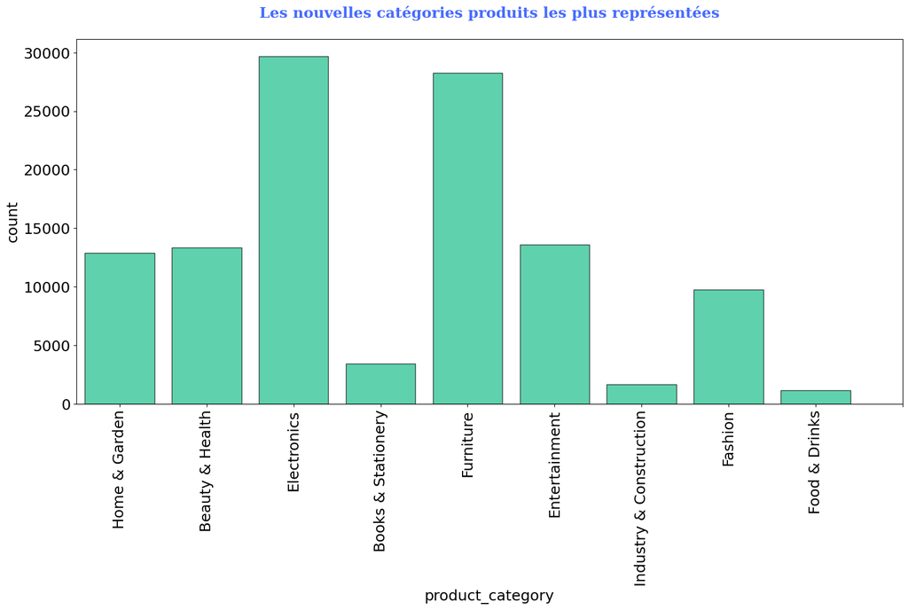

```python
# Plot categories count in dataset
font_title = {"family": "serif",
              "color":  "#476bff",
              "weight": "bold",
              "size": 18}
fig = plt.figure(figsize=(18, 8))
sns.countplot(data=df_synt, x="product_category",
              edgecolor="black",
              color="#00d994", alpha=0.7)
plt.xticks(range(0, df_synt["product_category"].nunique()+1),
           df_synt["product_category"].unique(),
           rotation=90)
plt.title(f"Les nouvelles catégories produits les plus représentées\n",
          fontdict=font_title)
plt.show()
```

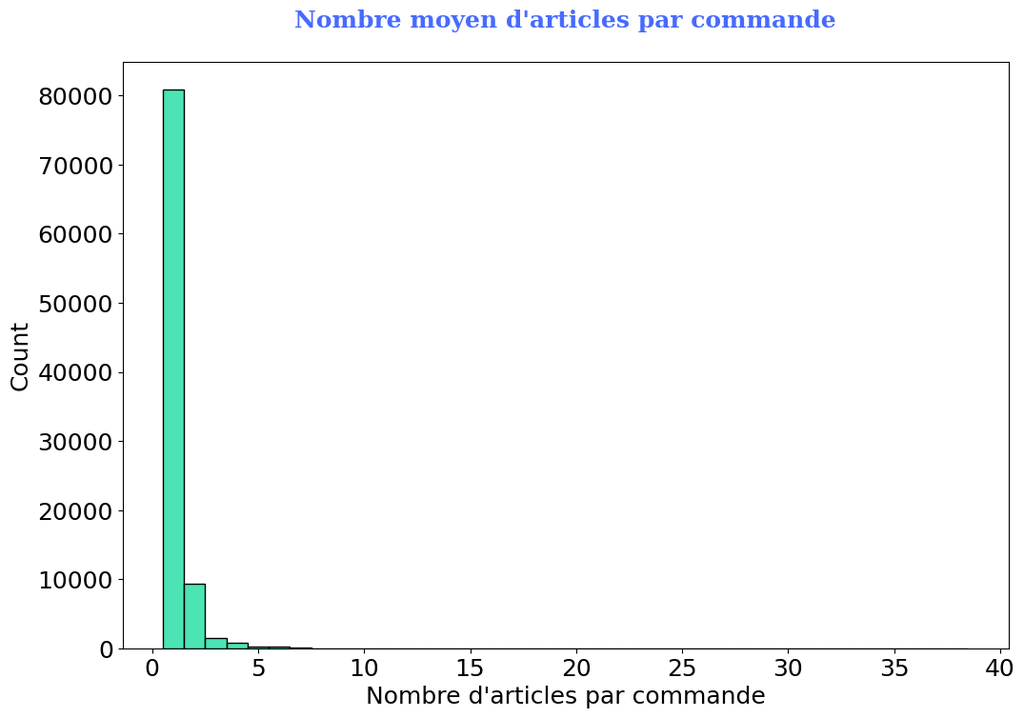

```python
products_per_order = df_synt.groupby(["customer_unique_id", "order_id"])\
                        .agg({"order_item_id": "count"})
products_per_order = products_per_order.groupby("customer_unique_id")\
                        .agg({"order_item_id": "mean"})

# Plot density of number items in order
fig = plt.figure(figsize=(12, 8))
sns.histplot(data = products_per_order,
             x="order_item_id",
             discrete=True,
             edgecolor="black",
             color="#00d994", alpha=0.7)
plt.xlabel("Nombre d'articles par commande")
plt.title(f"Nombre moyen d'articles par commande\n",
          fontdict=font_title)
plt.show()
```

### Classification des durées en 'OnTime/Early' & 'Late'

```python
#  Classification des durées en  'OnTime/Early' & 'Late'
df_synt['ponctualité_livraison_vendeur_relais'] = df_synt['delta_seller_to_carrier_status'].apply(
    lambda x : 'OnTime/Early' if x >=0 else 'Late')
df_synt['ponctualité_livraison_client'] = df_synt['differentiel_date_prevue'].apply(
    lambda x : 'OnTime/Early' if x >=0 else 'Late')
```

```python
df_synt
```

|  | order_id | customer_id | order_purchase_timestamp | order_approved_at | order_delivered_carrier_date | order_delivered_customer_date | order_estimated_delivery_date | customer_unique_id | customer_zip_code_prefix | customer_city | customer_state | review_id | review_score | review_comment_title | review_comment_message | review_creation_date | review_answer_timestamp | Satisfaction | Satisfaction_num | order_item_id | product_id | seller_id | shipping_limit_date | price | freight_value | product_category_name | product_name_lenght | product_description_lenght | product_photos_qty | … |
| --- | --- | --- | --- | --- | --- | --- | --- | --- | --- | --- | --- | --- | --- | --- | --- | --- | --- | --- | --- | --- | --- | --- | --- | --- | --- | --- | --- | --- | --- | --- |
| 0 | e481f51cbdc54678b7cc49136f2d6af7 | 9ef432eb6251297304e76186b10a928d | 2017-10-02 10:56:33 | 2017-10-02 11:07:15 | 2017-10-04 19:55:00 | 2017-10-10 21:25:13 | 2017-10-18 | 7c396fd4830fd04220f754e42b4e5bff | 3149 | sao paulo | SP | a54f0611adc9ed256b57ede6b6eb5114 | 4.0 | NaN | Não testei o produto ainda, mas ele veio corre... | 2017-10-11 | 2017-10-12 03:43:48 | Satisfied | 1.0 | 1 | 87285b34884572647811a353c7ac498a | 3504c0cb71d7fa48d967e0e4c94d59d9 | 2017-10-06 11:07:15 | 29.99 | 8.72 | utilidades_domesticas | 40.0 | 268.0 | 4.0 | … |
| 1 | e481f51cbdc54678b7cc49136f2d6af7 | 9ef432eb6251297304e76186b10a928d | 2017-10-02 10:56:33 | 2017-10-02 11:07:15 | 2017-10-04 19:55:00 | 2017-10-10 21:25:13 | 2017-10-18 | 7c396fd4830fd04220f754e42b4e5bff | 3149 | sao paulo | SP | a54f0611adc9ed256b57ede6b6eb5114 | 4.0 | NaN | Não testei o produto ainda, mas ele veio corre... | 2017-10-11 | 2017-10-12 03:43:48 | Satisfied | 1.0 | 1 | 87285b34884572647811a353c7ac498a | 3504c0cb71d7fa48d967e0e4c94d59d9 | 2017-10-06 11:07:15 | 29.99 | 8.72 | utilidades_domesticas | 40.0 | 268.0 | 4.0 | … |
| 2 | e481f51cbdc54678b7cc49136f2d6af7 | 9ef432eb6251297304e76186b10a928d | 2017-10-02 10:56:33 | 2017-10-02 11:07:15 | 2017-10-04 19:55:00 | 2017-10-10 21:25:13 | 2017-10-18 | 7c396fd4830fd04220f754e42b4e5bff | 3149 | sao paulo | SP | a54f0611adc9ed256b57ede6b6eb5114 | 4.0 | NaN | Não testei o produto ainda, mas ele veio corre... | 2017-10-11 | 2017-10-12 03:43:48 | Satisfied | 1.0 | 1 | 87285b34884572647811a353c7ac498a | 3504c0cb71d7fa48d967e0e4c94d59d9 | 2017-10-06 11:07:15 | 29.99 | 8.72 | utilidades_domesticas | 40.0 | 268.0 | 4.0 | … |
| 3 | 53cdb2fc8bc7dce0b6741e2150273451 | b0830fb4747a6c6d20dea0b8c802d7ef | 2018-07-24 20:41:37 | 2018-07-26 03:24:27 | 2018-07-26 14:31:00 | 2018-08-07 15:27:45 | 2018-08-13 | af07308b275d755c9edb36a90c618231 | 47813 | barreiras | BA | 8d5266042046a06655c8db133d120ba5 | 4.0 | Muito boa a loja | Muito bom o produto. | 2018-08-08 | 2018-08-08 18:37:50 | Satisfied | 1.0 | 1 | 595fac2a385ac33a80bd5114aec74eb8 | 289cdb325fb7e7f891c38608bf9e0962 | 2018-07-30 03:24:27 | 118.70 | 22.76 | perfumaria | 29.0 | 178.0 | 1.0 | … |
| 4 | 47770eb9100c2d0c44946d9cf07ec65d | 41ce2a54c0b03bf3443c3d931a367089 | 2018-08-08 08:38:49 | 2018-08-08 08:55:23 | 2018-08-08 13:50:00 | 2018-08-17 18:06:29 | 2018-09-04 | 3a653a41f6f9fc3d2a113cf8398680e8 | 75265 | vianopolis | GO | e73b67b67587f7644d5bd1a52deb1b01 | 5.0 | NaN | NaN | 2018-08-18 | 2018-08-22 19:07:58 | Satisfied | 1.0 | 1 | aa4383b373c6aca5d8797843e5594415 | 4869f7a5dfa277a7dca6462dcf3b52b2 | 2018-08-13 08:55:23 | 159.90 | 19.22 | automotivo | 46.0 | 232.0 | 1.0 | … |
| ... | ... | ... | ... | ... | ... | ... | ... | ... | ... | ... | ... | ... | ... | ... | ... | ... | ... | ... | ... | ... | ... | ... | ... | ... | ... | ... | ... | ... | ... | … |
| 115694 | 63943bddc261676b46f01ca7ac2f7bd8 | 1fca14ff2861355f6e5f14306ff977a7 | 2018-02-06 12:58:58 | 2018-02-06 13:10:37 | 2018-02-07 23:22:42 | 2018-02-28 17:37:56 | 2018-03-02 | da62f9e57a76d978d02ab5362c509660 | 11722 | praia grande | SP | 29bb71b2760d0f876dfa178a76bc4734 | 4.0 | NaN | So uma peça que veio rachado mas tudo bem rs | 2018-03-01 | 2018-03-02 17:50:01 | Satisfied | 1.0 | 1 | f1d4ce8c6dd66c47bbaa8c6781c2a923 | 1f9ab4708f3056ede07124aad39a2554 | 2018-02-12 13:10:37 | 174.90 | 20.10 | bebes | 52.0 | 828.0 | 4.0 | … |
| 115695 | 83c1379a015df1e13d02aae0204711ab | 1aa71eb042121263aafbe80c1b562c9c | 2017-08-27 14:46:43 | 2017-08-27 15:04:16 | 2017-08-28 20:52:26 | 2017-09-21 11:24:17 | 2017-09-27 | 737520a9aad80b3fbbdad19b66b37b30 | 45920 | nova vicosa | BA | 371579771219f6db2d830d50805977bb | 5.0 | NaN | Foi entregue antes do prazo. | 2017-09-22 | 2017-09-22 23:10:57 | Satisfied | 1.0 | 1 | b80910977a37536adeddd63663f916ad | d50d79cb34e38265a8649c383dcffd48 | 2017-09-05 15:04:16 | 205.99 | 65.02 | eletrodomesticos_2 | 51.0 | 500.0 | 2.0 | … |
| 115696 | 11c177c8e97725db2631073c19f07b62 | b331b74b18dc79bcdf6532d51e1637c1 | 2018-01-08 21:28:27 | 2018-01-08 21:36:21 | 2018-01-12 15:35:03 | 2018-01-25 23:32:54 | 2018-02-15 | 5097a5312c8b157bb7be58ae360ef43c | 28685 | japuiba | RJ | 8ab6855b9fe9b812cd03a480a25058a1 | 2.0 | NaN | Foi entregue somente 1. Quero saber do outro p... | 2018-01-26 | 2018-01-27 09:16:56 | Not Satisfied | -1.0 | 1 | d1c427060a0f73f6b889a5c7c61f2ac4 | a1043bafd471dff536d0c462352beb48 | 2018-01-12 21:36:21 | 179.99 | 40.59 | informatica_acessorios | 59.0 | 1893.0 | 1.0 | … |
| 115697 | 11c177c8e97725db2631073c19f07b62 | b331b74b18dc79bcdf6532d51e1637c1 | 2018-01-08 21:28:27 | 2018-01-08 21:36:21 | 2018-01-12 15:35:03 | 2018-01-25 23:32:54 | 2018-02-15 | 5097a5312c8b157bb7be58ae360ef43c | 28685 | japuiba | RJ | 8ab6855b9fe9b812cd03a480a25058a1 | 2.0 | NaN | Foi entregue somente 1. Quero saber do outro p... | 2018-01-26 | 2018-01-27 09:16:56 | Not Satisfied | -1.0 | 2 | d1c427060a0f73f6b889a5c7c61f2ac4 | a1043bafd471dff536d0c462352beb48 | 2018-01-12 21:36:21 | 179.99 | 40.59 | informatica_acessorios | 59.0 | 1893.0 | 1.0 | … |
| 115698 | 66dea50a8b16d9b4dee7af250b4be1a5 | edb027a75a1449115f6b43211ae02a24 | 2018-03-08 20:57:30 | 2018-03-09 11:20:28 | 2018-03-09 22:11:59 | 2018-03-16 13:08:30 | 2018-04-03 | 60350aa974b26ff12caad89e55993bd6 | 83750 | lapa | PR | dc9c59b4688062c25758c2be4cafc523 | 5.0 | NaN | NaN | 2018-03-17 | 2018-03-17 16:33:31 | Satisfied | 1.0 | 1 | 006619bbed68b000c8ba3f8725d5409e | ececbfcff9804a2d6b40f589df8eef2b | 2018-03-15 10:55:42 | 68.50 | 18.36 | beleza_saude | 45.0 | 569.0 | 1.0 | … |

115438 rows × 57 columns

```python
def boxplotdistandlog(variable,a,b):
    f, ax = plt.subplots(2, 2, figsize = (a,b), gridspec_kw = {"height_ratios": (.15, .85)})

    sns.boxplot(variable, ax = ax[0, 0], orient = "h")
    ax[0, 0].set(xlabel='')
    ax[0, 0].set_title("")
    sns.histplot(variable, ax = ax[1, 0])
    ax[1, 0].set(xlabel='')

    variable_log = np.log(variable + 1)
    sns.boxplot(variable_log, ax = ax[0, 1], orient = "h")
    ax[0, 1].set(xlabel='')
    ax[0, 1].set_title("")
    sns.histplot(variable_log, ax = ax[1, 1])
    ax[1, 1].set(xlabel='')


    plt.show()
    print("coefficient d'asymétrie:", variable.skew())
    print("coefficient d'asymétrie après transformation:", np.log(variable+1).skew())
```

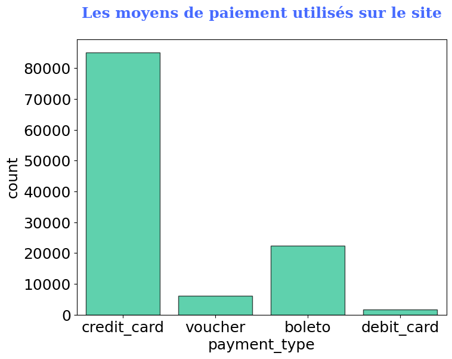

```python
fig = plt.figure(figsize=(8, 6))
sns.countplot(data=df_synt, x="payment_type",
              edgecolor="black",
              color="#00d994", alpha=0.7)
plt.title(f"Les moyens de paiement utilisés sur le site\n",
          fontdict=font_title)
plt.show()
```

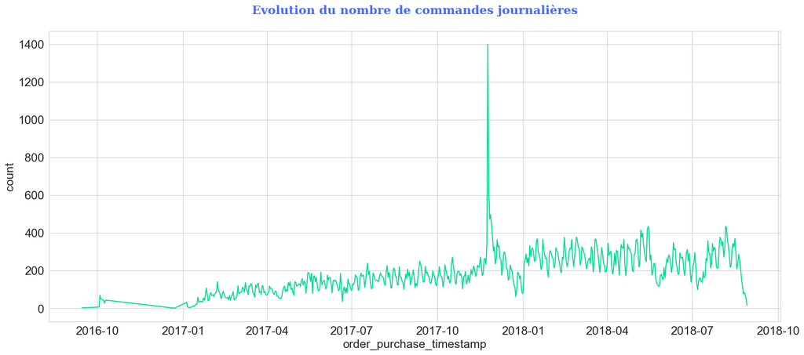

```python
#Evolution du nombre de commandes journalières
orders_per_days = df_synt.groupby(df_synt["order_purchase_timestamp"]\
                                      .astype('datetime64[ns]').dt.date)\
                                    .count()["order_id"]
sns.set_style("whitegrid")
font_title = {"family": "serif",
              "color":  "#476bff",
              "weight": "bold",
              "size": 18}
fig = plt.figure(figsize=(20, 8))
ax = orders_per_days.plot(color="#00d994")
ax.set_ylabel("count")
plt.title(f"Evolution du nombre de commandes journalières\n",
          fontdict=font_title)
plt.show()
```

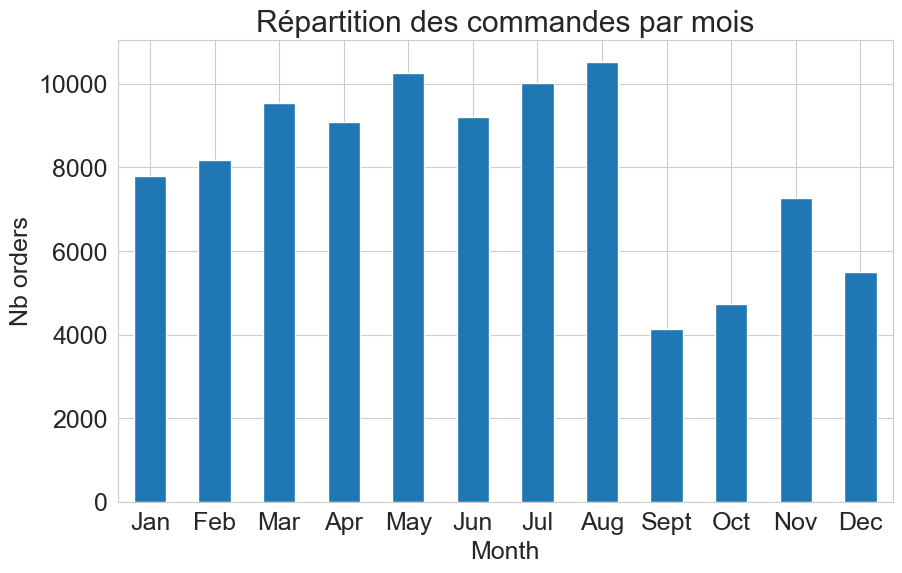

```python
df_synt.groupby(df_synt['order_purchase_timestamp'].dt.month)\
    .agg({"order_id": "nunique"})\
    .plot(figsize=(10,6), kind="bar",
          title="Répartition des commandes par mois",
          ylabel="Nb orders",
          xlabel="Month",
          legend=False)
plt.xticks(np.arange(0,12), ['Jan','Feb','Mar','Apr','May','Jun',
                             'Jul','Aug','Sept','Oct','Nov','Dec'],
           rotation='horizontal')
plt.show()
```

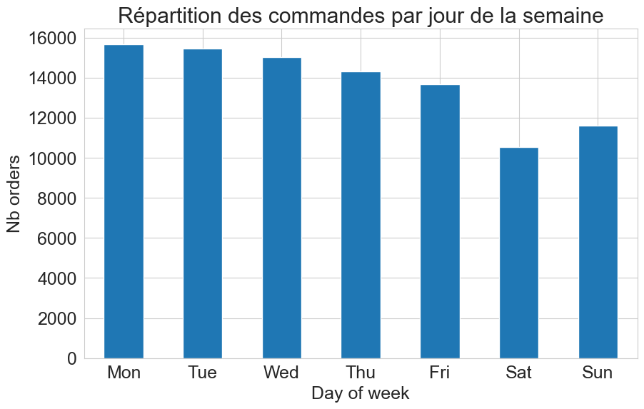

```python
df_synt.groupby(df_synt['order_purchase_timestamp'].dt.dayofweek)\
    .agg({"order_id": "nunique"})\
    .plot(figsize=(10,6), kind="bar",
          title="Répartition des commandes par jour de la semaine",
          ylabel="Nb orders",
          xlabel="Day of week",
          legend=False)
plt.xticks(np.arange(0,7), ['Mon','Tue','Wed','Thu','Fri','Sat','Sun'], rotation='horizontal')
plt.show()
```

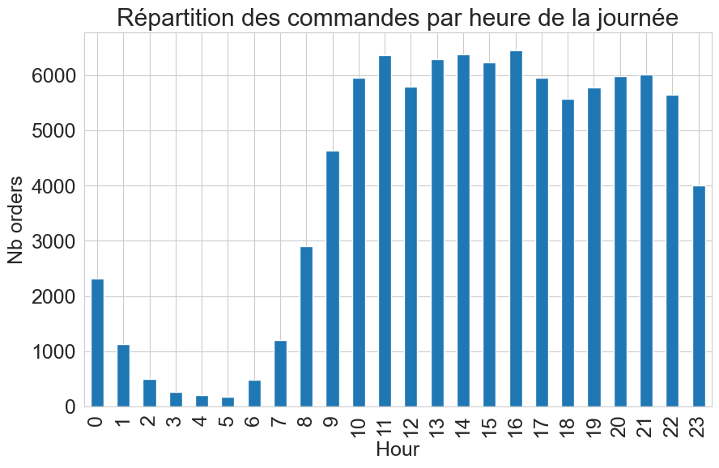

```python
df_synt.groupby(df_synt['order_purchase_timestamp'].dt.hour)\
    .agg({"order_id": "nunique"})\
    .plot(figsize=(10,6), kind="bar",
          title="Répartition des commandes par heure de la journée",
          ylabel="Nb orders",
          xlabel="Hour",
          legend=False)
plt.show()
```

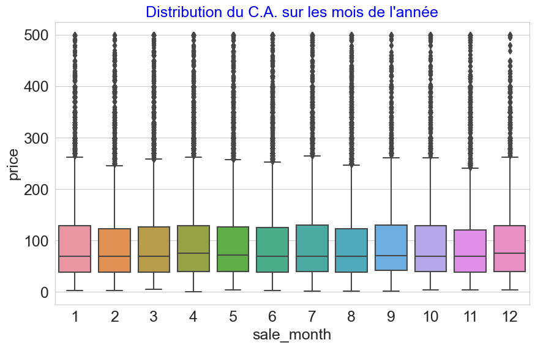

```python
df_synt["sale_month"] = df_synt['order_purchase_timestamp'].dt.month
fig = plt.figure(figsize=(10,6))
sns.boxplot(data=df_synt[df_synt.price < 500], x="sale_month", y="price")
plt.title("Distribution du C.A. sur les mois de l'année", fontsize=18, color="b")
plt.show()
```

```python
def boxplotdist(variable,a,b):
    f, (ax_box, ax_hist) = plt.subplots(2,figsize=(a,b), sharex=True, gridspec_kw={"height_ratios": (.15, .85)})
    sns.boxplot(variable, ax=ax_box, orient="h")
#sns.histplot(data=df_clean_reels, x="additives_n", ax=ax_hist)
    sns.histplot(variable, ax=ax_hist)
    ax_box.set(xlabel='')
    plt.show()
    print("coefficient d'asymétrie:", variable.skew())
```

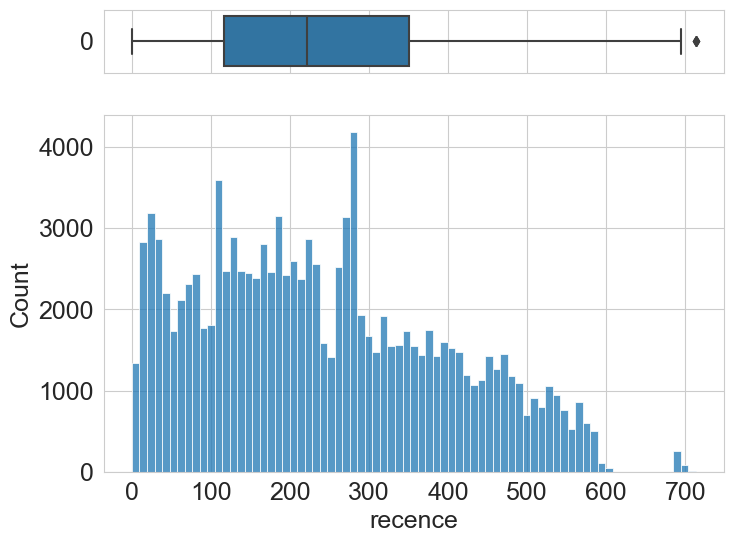

```
coefficient d'asymétrie: 0.4264775685192283
```

```python
# Détection des outliers sur les variables recence et payment_value
boxplotdist(df_synt['recence'], 8,6)
```

```python
df_synt[df_synt['recence']>595]
```

|  | order_id | customer_id | order_purchase_timestamp | order_approved_at | order_delivered_carrier_date | order_delivered_customer_date | order_estimated_delivery_date | customer_unique_id | customer_zip_code_prefix | customer_city | customer_state | review_id | review_score | review_comment_title | review_comment_message | review_creation_date | review_answer_timestamp | Satisfaction | Satisfaction_num | order_item_id | product_id | seller_id | shipping_limit_date | price | freight_value | product_category_name | product_name_lenght | product_description_lenght | product_photos_qty | … |
| --- | --- | --- | --- | --- | --- | --- | --- | --- | --- | --- | --- | --- | --- | --- | --- | --- | --- | --- | --- | --- | --- | --- | --- | --- | --- | --- | --- | --- | --- | --- |
| 276 | f175d67589e059cbbda956f10f0702e6 | a4555d257db29ef5f838cec4101c5208 | 2017-01-05 13:34:35 | 2017-01-07 03:45:40 | 2017-01-11 16:25:57 | 2017-01-17 15:52:28 | 2017-02-13 | f7be9bec658c62ab6240b44cd26c0b84 | 80030 | curitiba | PR | 369c19f8a738d263852a7b500bcfba59 | 5.0 | NaN | Produto de boa qualidade, chegou antes do praz... | 2017-01-18 | 2017-01-18 10:52:04 | Satisfied | 1.0 | 1 | d8c365a069853295a82caf595c2c8c8d | 48efc9d94a9834137efd9ea76b065a38 | 2017-01-09 13:34:35 | 9.90 | 8.72 | moveis_quarto | 55.0 | 1931.0 | 1.0 | … |
| 437 | cbbb524a0e1646aa6cf7a3c0bbe517ad | dacb079d55ffb1d3955c5d923df3ebb7 | 2016-10-05 07:31:49 | 2016-10-06 02:46:24 | 2016-10-10 02:46:24 | 2016-10-16 14:36:00 | 2016-12-07 | 12cc890391e57d7123e004856ff1f137 | 50090 | recife | PE | 6f97d8b5afaf78f8658cfc0634840b40 | 1.0 | NaN | produto entregue diferente do que foi comprado... | 2016-10-21 | 2016-10-22 10:10:28 | Not Satisfied | -1.0 | 1 | bab7ff9abbcc13690a62d015f2ca8e44 | 229c3efbfb0ea2058de4ccdfbc3d784a | 2016-10-10 02:46:24 | 75.00 | 20.58 | informatica_acessorios | 43.0 | 269.0 | 1.0 | … |
| 819 | ac2b7c522d811acba0aa270ed3e112e4 | ef21aebbb093a6db29ccc6aa0b89c347 | 2016-10-05 15:08:00 | 2016-10-06 15:44:26 | 2016-10-10 15:44:27 | 2016-10-13 15:44:27 | 2016-11-29 | 664f7107c351f24b16b68919398730a0 | 13610 | leme | SP | efef5a00aac989951350619e06681dcb | 1.0 | NaN | Loja lixo, entregaram produto errado, mandei e... | 2016-10-22 | 2016-10-24 23:33:19 | Not Satisfied | -1.0 | 1 | 4632bc49b300378ed4f1d48f424d414e | ed859002ad59dbf8cf3602696a6c3000 | 2016-10-10 15:44:27 | 294.90 | 20.34 | automotivo | 33.0 | 513.0 | 2.0 | … |
| 1090 | 747996a66f5aa711deb8ae58f5ae46a0 | ed1793d2d1e4175d5846ce7ebb4a01f5 | 2017-01-05 15:25:10 | 2017-01-07 03:44:28 | 2017-01-11 15:59:08 | 2017-01-16 15:18:08 | 2017-02-13 | 12f5d6e1cbf93dafd9dcc19095df0b3d | 82200 | curitiba | PR | e5d48386325f21f0360c77b19c77feb1 | 5.0 | NaN | Recebi bem antes do prazo informado e o produt... | 2017-01-17 | 2017-01-17 12:54:52 | Satisfied | 1.0 | 1 | 2797d3826d386bfda4f347a378b89f4d | 48efc9d94a9834137efd9ea76b065a38 | 2017-01-09 15:25:10 | 9.90 | 8.72 | pet_shop | 36.0 | 142.0 | 1.0 | … |
| 1619 | 7033745709b7cf1bac7d2533663592de | 7f0ca17bb33b230b47459437cf0682c7 | 2016-10-04 14:13:22 | 2016-10-04 14:46:48 | 2016-10-08 14:46:49 | 2016-10-11 14:46:49 | 2016-11-30 | 1dc848c11c2985635c268ff3dea707eb | 21853 | rio de janeiro | RJ | a0ba97ce98f76cf57bb2c5530513be70 | 3.0 | NaN | dentro do anunciado. | 2016-10-25 | 2016-10-26 23:52:15 | Not Satisfied | -1.0 | 1 | 35084deab9603bbb6035bb8638b1df89 | df560393f3a51e74553ab94004ba5c87 | 2016-10-08 14:46:49 | 93.90 | 17.61 | moveis_decoracao | 49.0 | 100.0 | 1.0 | … |
| ... | ... | ... | ... | ... | ... | ... | ... | ... | ... | ... | ... | ... | ... | ... | ... | ... | ... | ... | ... | ... | ... | ... | ... | ... | ... | ... | ... | ... | ... | … |
| 114361 | 6e0d2539e48e84296bae6290de41058c | 1fc56719b52f82c03caddc5faf531fbb | 2016-10-04 19:41:52 | 2016-10-06 15:51:37 | 2016-11-10 16:47:52 | 2016-11-17 09:23:50 | 2016-11-30 | 40b41ade17bb2121b576b07e25ce622b | 95500 | santo antonio da patrulha | RS | 5d81c62be8e72b14a0c9b208ffeb5d5d | 5.0 | NaN | NaN | 2016-11-18 | 2016-11-19 10:01:20 | Satisfied | 1.0 | 1 | 4fee671ea459ebc96546523917e254a5 | 822b63912576852aea9a8436d72317b7 | 2016-10-21 16:19:48 | 949.99 | 32.42 | consoles_games | 63.0 | 2872.0 | 7.0 | … |
| 114555 | 9d664ec86be69d869bb6870294c4fdd8 | 0a9ee4d9030acbe428769c79d0c4da69 | 2016-10-08 15:02:10 | 2016-10-08 19:55:50 | 2016-10-12 19:55:50 | 2016-10-31 11:35:45 | 2016-12-12 | d0f63e7f9adb09e4efc7f4f276b977e4 | 45355 | apuarema | BA | 63593aa97da5e0e27664cd382a30f372 | 4.0 | NaN | gostei bastante, fiquei satisfeito | 2016-11-01 | 2016-11-03 23:59:19 | Satisfied | 1.0 | 1 | d26580768894ea0cdc9f19dc672956c2 | d50d79cb34e38265a8649c383dcffd48 | 2016-10-12 19:55:50 | 169.99 | 34.39 | utilidades_domesticas | 44.0 | 586.0 | 3.0 | … |
| 115223 | 7e2dddf174cc4d2768bf39c43ab2bd7a | accfbaa1f092fdf6db1d8fcdad351b50 | 2016-10-09 15:10:41 | 2016-10-10 05:54:51 | 2016-11-03 07:43:55 | 2016-11-10 09:27:42 | 2016-12-02 | 1c5aefec1a2943edd15e52f9e2900e41 | 39860 | nanuque | MG | a450b65b40eef4bd63aed18e935770b6 | 1.0 | NaN | Meu produto veio com defeitoem uma das peças .... | 2016-11-11 | 2016-11-12 09:59:18 | Not Satisfied | -1.0 | 1 | e41a6ac2f57a273eb0d214c7cbab5db9 | a7f13822ceb966b076af67121f87b063 | 2016-10-14 05:54:52 | 129.97 | 29.38 | moveis_escritorio | 56.0 | 1085.0 | 1.0 | … |
| 115472 | e439ced3d48f1a77f6ecc029cc946a6f | e9c6723e04c4e53e7e9c3afe383f3866 | 2016-10-07 22:35:59 | 2016-10-07 22:59:53 | 2016-10-15 10:31:09 | 2016-10-25 21:15:45 | 2016-12-01 | 84717d840af87a7fa12a66a0933ede2a | 13720 | sao jose do rio pardo | SP | d6057688274ddb3b9f7d9fcf7ec9b286 | 3.0 | NaN | produto artesanal, eu mesmo deveria ter feito.... | 2016-10-26 | 2016-10-31 13:13:56 | Not Satisfied | -1.0 | 1 | a694f2632fae82ef419fd71587103dc9 | 989becdce12ebc39863c2bceab6f3ca1 | 2016-10-11 22:59:53 | 138.00 | 22.44 | esporte_lazer | 44.0 | 461.0 | 1.0 | … |
| 115516 | 509a52223ecac6d67fb765b3b37c6974 | efc07f50d0a9346ec00e1c37b5b10748 | 2016-10-06 18:11:11 | 2016-10-06 18:50:35 | 2016-10-21 16:23:01 | 2016-10-26 12:21:06 | 2016-12-08 | 11a40baf46bd96289d1f0936dae9a256 | 74015 | goiania | GO | 499bbf4c80a2bfb703f60df742c3cb92 | 5.0 | NaN | Recebi o produto no prazo, em perfeitas condiç... | 2016-10-27 | 2016-10-28 17:46:59 | Satisfied | 1.0 | 1 | 10dd77710da08ea43018cb3b4cedff92 | 38e679b9e0064cd94c6f035707344dae | 2016-10-21 16:23:01 | 44.90 | 20.80 | esporte_lazer | 58.0 | 1185.0 | 3.0 | … |

399 rows × 58 columns

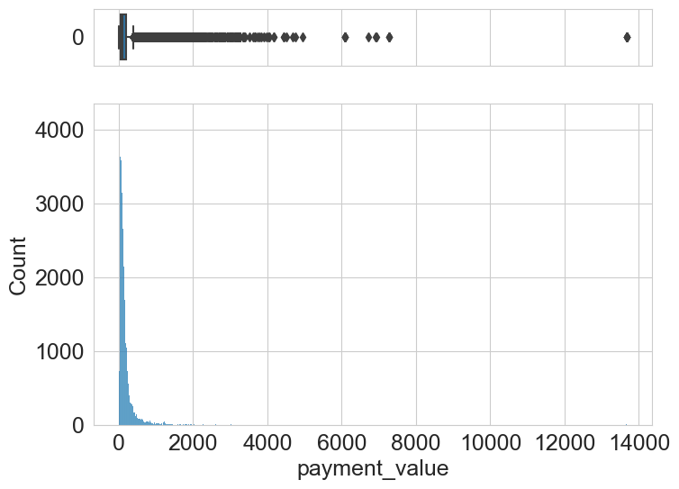

```
coefficient d'asymétrie: 14.402418887866562
```

```python
boxplotdist(df_synt['payment_value'], 8,6)
```

```python
df_synt[df_synt['payment_value']>12000]
```

|  | order_id | customer_id | order_purchase_timestamp | order_approved_at | order_delivered_carrier_date | order_delivered_customer_date | order_estimated_delivery_date | customer_unique_id | customer_zip_code_prefix | customer_city | customer_state | review_id | review_score | review_comment_title | review_comment_message | review_creation_date | review_answer_timestamp | Satisfaction | Satisfaction_num | order_item_id | product_id | seller_id | shipping_limit_date | price | freight_value | product_category_name | product_name_lenght | product_description_lenght | product_photos_qty | … |
| --- | --- | --- | --- | --- | --- | --- | --- | --- | --- | --- | --- | --- | --- | --- | --- | --- | --- | --- | --- | --- | --- | --- | --- | --- | --- | --- | --- | --- | --- | --- |
| 15487 | 03caa2c082116e1d31e67e9ae3700499 | 1617b1357756262bfa56ab541c47bc16 | 2017-09-29 15:24:52 | 2017-10-02 15:28:20 | 2017-10-10 15:43:17 | 2017-10-17 18:22:29 | 2017-10-23 | 0a0a92112bd4c708ca5fde585afaa872 | 20080 | rio de janeiro | RJ | 211fa81a22870cc634265ea85b751e40 | 1.0 | NaN | Peço por favor verificar a entrega do pedido, ... | 2017-10-18 | 2017-10-19 13:10:39 | Not Satisfied | -1.0 | 1 | 5769ef0a239114ac3a854af00df129e4 | b37c4c02bda3161a7546a4e6d222d5b2 | 2017-10-06 15:28:20 | 1680.0 | 28.01 | telefonia_fixa | 39.0 | 2493.0 | 3.0 | … |
| 15488 | 03caa2c082116e1d31e67e9ae3700499 | 1617b1357756262bfa56ab541c47bc16 | 2017-09-29 15:24:52 | 2017-10-02 15:28:20 | 2017-10-10 15:43:17 | 2017-10-17 18:22:29 | 2017-10-23 | 0a0a92112bd4c708ca5fde585afaa872 | 20080 | rio de janeiro | RJ | 211fa81a22870cc634265ea85b751e40 | 1.0 | NaN | Peço por favor verificar a entrega do pedido, ... | 2017-10-18 | 2017-10-19 13:10:39 | Not Satisfied | -1.0 | 2 | 5769ef0a239114ac3a854af00df129e4 | b37c4c02bda3161a7546a4e6d222d5b2 | 2017-10-06 15:28:20 | 1680.0 | 28.01 | telefonia_fixa | 39.0 | 2493.0 | 3.0 | … |
| 15489 | 03caa2c082116e1d31e67e9ae3700499 | 1617b1357756262bfa56ab541c47bc16 | 2017-09-29 15:24:52 | 2017-10-02 15:28:20 | 2017-10-10 15:43:17 | 2017-10-17 18:22:29 | 2017-10-23 | 0a0a92112bd4c708ca5fde585afaa872 | 20080 | rio de janeiro | RJ | 211fa81a22870cc634265ea85b751e40 | 1.0 | NaN | Peço por favor verificar a entrega do pedido, ... | 2017-10-18 | 2017-10-19 13:10:39 | Not Satisfied | -1.0 | 3 | 5769ef0a239114ac3a854af00df129e4 | b37c4c02bda3161a7546a4e6d222d5b2 | 2017-10-06 15:28:20 | 1680.0 | 28.01 | telefonia_fixa | 39.0 | 2493.0 | 3.0 | … |
| 15490 | 03caa2c082116e1d31e67e9ae3700499 | 1617b1357756262bfa56ab541c47bc16 | 2017-09-29 15:24:52 | 2017-10-02 15:28:20 | 2017-10-10 15:43:17 | 2017-10-17 18:22:29 | 2017-10-23 | 0a0a92112bd4c708ca5fde585afaa872 | 20080 | rio de janeiro | RJ | 211fa81a22870cc634265ea85b751e40 | 1.0 | NaN | Peço por favor verificar a entrega do pedido, ... | 2017-10-18 | 2017-10-19 13:10:39 | Not Satisfied | -1.0 | 4 | 5769ef0a239114ac3a854af00df129e4 | b37c4c02bda3161a7546a4e6d222d5b2 | 2017-10-06 15:28:20 | 1680.0 | 28.01 | telefonia_fixa | 39.0 | 2493.0 | 3.0 | … |
| 15491 | 03caa2c082116e1d31e67e9ae3700499 | 1617b1357756262bfa56ab541c47bc16 | 2017-09-29 15:24:52 | 2017-10-02 15:28:20 | 2017-10-10 15:43:17 | 2017-10-17 18:22:29 | 2017-10-23 | 0a0a92112bd4c708ca5fde585afaa872 | 20080 | rio de janeiro | RJ | 211fa81a22870cc634265ea85b751e40 | 1.0 | NaN | Peço por favor verificar a entrega do pedido, ... | 2017-10-18 | 2017-10-19 13:10:39 | Not Satisfied | -1.0 | 5 | 5769ef0a239114ac3a854af00df129e4 | b37c4c02bda3161a7546a4e6d222d5b2 | 2017-10-06 15:28:20 | 1680.0 | 28.01 | telefonia_fixa | 39.0 | 2493.0 | 3.0 | … |
| 15492 | 03caa2c082116e1d31e67e9ae3700499 | 1617b1357756262bfa56ab541c47bc16 | 2017-09-29 15:24:52 | 2017-10-02 15:28:20 | 2017-10-10 15:43:17 | 2017-10-17 18:22:29 | 2017-10-23 | 0a0a92112bd4c708ca5fde585afaa872 | 20080 | rio de janeiro | RJ | 211fa81a22870cc634265ea85b751e40 | 1.0 | NaN | Peço por favor verificar a entrega do pedido, ... | 2017-10-18 | 2017-10-19 13:10:39 | Not Satisfied | -1.0 | 6 | 5769ef0a239114ac3a854af00df129e4 | b37c4c02bda3161a7546a4e6d222d5b2 | 2017-10-06 15:28:20 | 1680.0 | 28.01 | telefonia_fixa | 39.0 | 2493.0 | 3.0 | … |
| 15493 | 03caa2c082116e1d31e67e9ae3700499 | 1617b1357756262bfa56ab541c47bc16 | 2017-09-29 15:24:52 | 2017-10-02 15:28:20 | 2017-10-10 15:43:17 | 2017-10-17 18:22:29 | 2017-10-23 | 0a0a92112bd4c708ca5fde585afaa872 | 20080 | rio de janeiro | RJ | 211fa81a22870cc634265ea85b751e40 | 1.0 | NaN | Peço por favor verificar a entrega do pedido, ... | 2017-10-18 | 2017-10-19 13:10:39 | Not Satisfied | -1.0 | 7 | 5769ef0a239114ac3a854af00df129e4 | b37c4c02bda3161a7546a4e6d222d5b2 | 2017-10-06 15:28:20 | 1680.0 | 28.01 | telefonia_fixa | 39.0 | 2493.0 | 3.0 | … |
| 15494 | 03caa2c082116e1d31e67e9ae3700499 | 1617b1357756262bfa56ab541c47bc16 | 2017-09-29 15:24:52 | 2017-10-02 15:28:20 | 2017-10-10 15:43:17 | 2017-10-17 18:22:29 | 2017-10-23 | 0a0a92112bd4c708ca5fde585afaa872 | 20080 | rio de janeiro | RJ | 211fa81a22870cc634265ea85b751e40 | 1.0 | NaN | Peço por favor verificar a entrega do pedido, ... | 2017-10-18 | 2017-10-19 13:10:39 | Not Satisfied | -1.0 | 8 | 5769ef0a239114ac3a854af00df129e4 | b37c4c02bda3161a7546a4e6d222d5b2 | 2017-10-06 15:28:20 | 1680.0 | 28.01 | telefonia_fixa | 39.0 | 2493.0 | 3.0 | … |